# Task 1

## Anscombe’s data set

• Scatter plot facetted by set

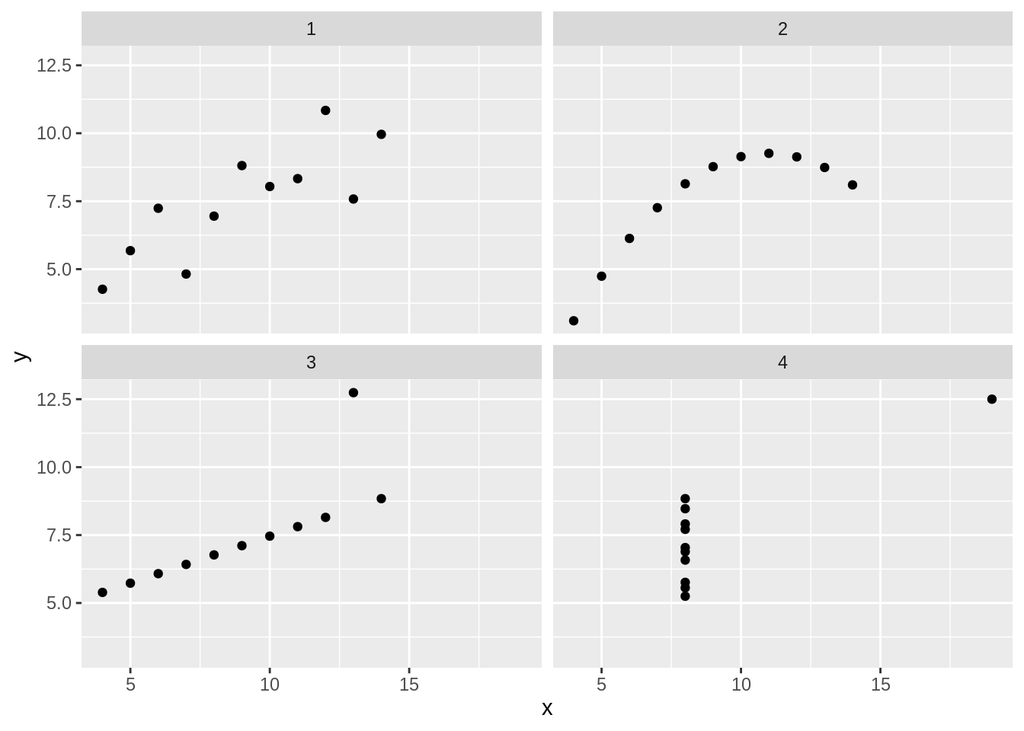

```r
data <- data.frame('x' = c(anscombe$x1, anscombe$x2, anscombe$x3, anscombe$x4),
                   'y' = c(anscombe$y1, anscombe$y2, anscombe$y3, anscombe$y4),
                   'set' =  rep(c(1:4), each = 11))
ggplot(data, aes(x, y)) +
  geom_point() +
  facet_wrap(~ set)
```

• Summary calculation (mean, sd) grouped by set

```r
setNames(aggregate(data[, 1:2], list(data$set), mean), c('set', 'mean_x', 'mean_y'))
```

| set | mean_x | mean_y |
| --- | --- | --- |
| 1 | 9 | 7.500909 |
| 2 | 9 | 7.500909 |
| 3 | 9 | 7.500000 |
| 4 | 9 | 7.500909 |

```r
setNames(aggregate(data[, 1:2], list('Sd' = data$set), sd),  c('set', 'sd_x', 'sd_y'))
```

| set | sd_x | sd_y |
| --- | --- | --- |
| 1 | 3.316625 | 2.031568 |
| 2 | 3.316625 | 2.031657 |
| 3 | 3.316625 | 2.030424 |
| 4 | 3.316625 | 2.030579 |

• Pearson’s correlation by set, and non-parametric, and p-value

```r
data %>% group_by(set) %>% summarise(cor_pearson = cor.test(x,y, method = 'pearson')$estimate,
                                      cor_kendall = cor.test(x,y, method = 'kendall')$estimate,
                                      cor_spearmen = cor.test(x,y, method = 'spearman')$estimate)
```

| set | cor_pearson | cor_kendall | cor_spearmen |
| --- | --- | --- | --- |
| 1 | 0.8164205 | 0.6363636 | 0.8181818 |
| 2 | 0.8162365 | 0.5636364 | 0.6909091 |
| 3 | 0.8162867 | 0.9636364 | 0.9909091 |
| 4 | 0.8165214 | 0.4264014 | 0.5000000 |

```r
data %>% group_by(set) %>% summarise(p_pearson = cor.test(x,y, method = 'pearson')$p.value,
                                     p_kendall = cor.test(x,y, method = 'kendall')$p.value,
                                     p_spearmen = cor.test(x,y, method = 'spearman')$p.value)
```

| set | p_pearson | p_kendall | p_spearmen |
| --- | --- | --- | --- |
| 1 | 0.002169629 | 5.707171e-03 | 0.003734471 |
| 2 | 0.002178816 | 1.654050e-02 | 0.023058874 |
| 3 | 0.002176305 | 5.511464e-07 | 0.000000000 |
| 4 | 0.002164602 | 1.138463e-01 | 0.117306803 |

• Add geom_smooth() to the plot

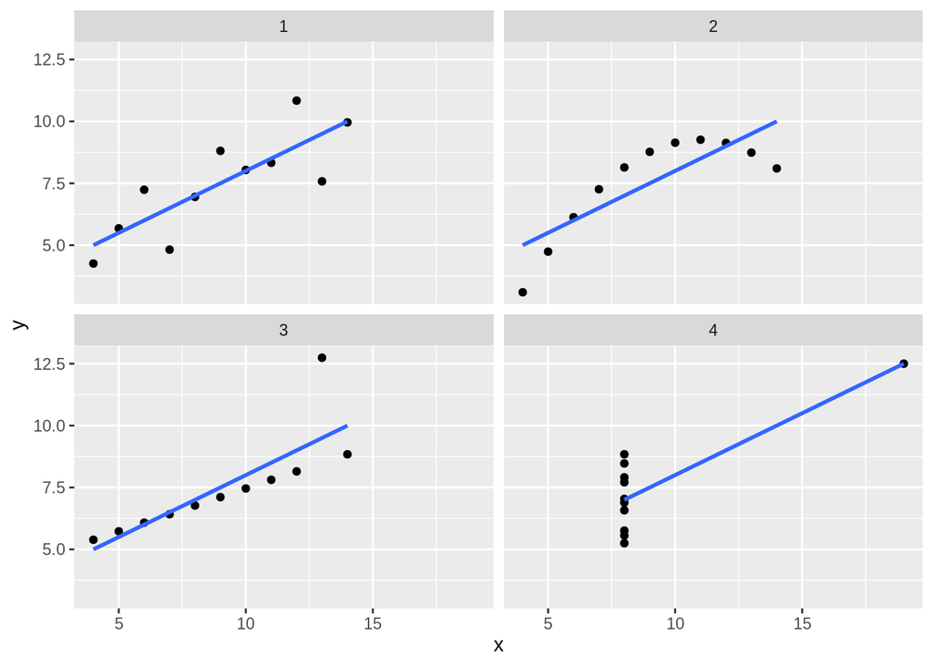

```r
ggplot(data, aes(x, y)) +
  geom_point() +
  geom_smooth(method = lm, se = FALSE) +
  facet_wrap(~ set)
```

## Air Quality data set

```r
airq_data <- read.csv('/home/marina/Загрузки/AirQualityUCI.csv', sep = ';')
```

• Deleting NA columns and rows. Averaged concentration CO, Averaged Benzene concentration, Temperature, Humidity are factor columns in data, so it will be better to convert them into numeric. Actually, I don’t need date and time for futher analysis, so I will slice the data.

```r
airq_data <- airq_data %>% select_if(~sum(!is.na(.)) > 0)  %>% drop_na()
airq_data[c('CO.GT.', 'C6H6.GT.', 'T', 'RH', 'AH')] <-  sapply(airq_data[c('CO.GT.', 'C6H6.GT.', 'T', 'RH', 'AH')], as.numeric)
airq_data <- airq_data[, c(3:15)]
```

• Exploring the variables (I make it in a 3 parts to better visualizing)

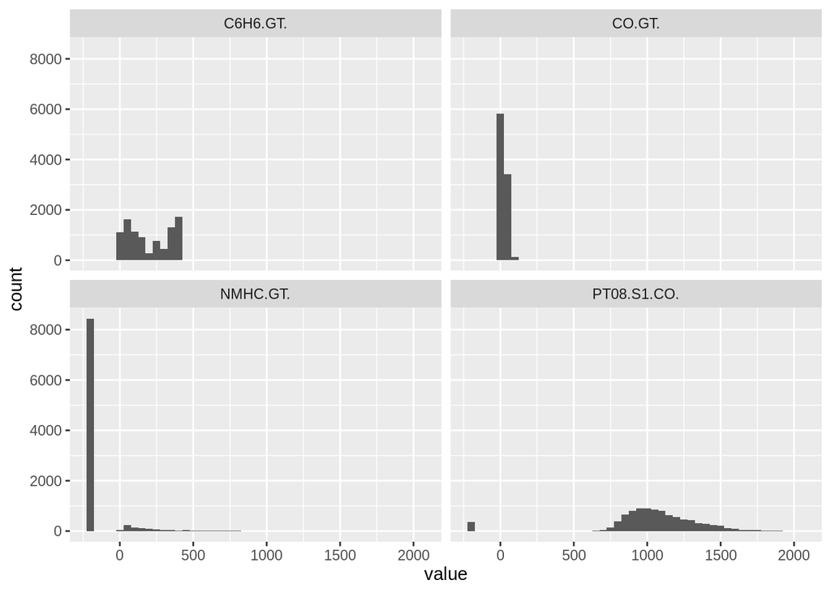

```r
ggplot(gather(airq_data[, c(1:4)], cols, value), aes(x = value)) +
  geom_histogram(binwidth = 50) + facet_wrap(.~cols)
```

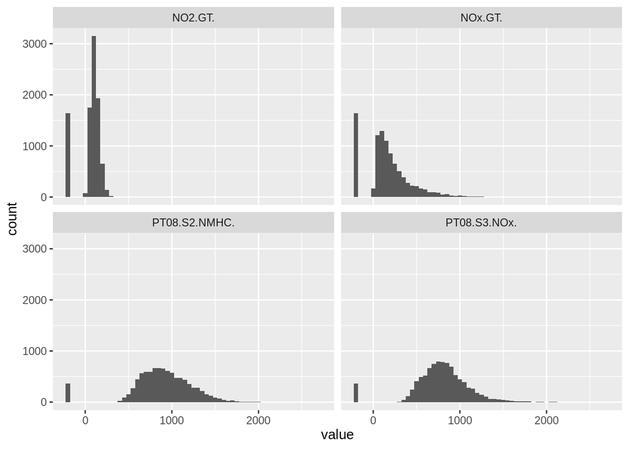

```r
ggplot(gather(airq_data[, c(5:8)], cols, value), aes(x = value)) +
  geom_histogram(binwidth = 50) + facet_wrap(.~cols)
```

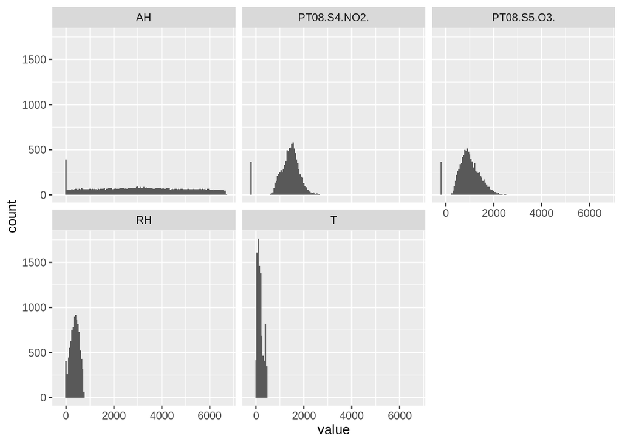

```r
ggplot(gather(airq_data[, c(9:13)], cols, value), aes(x = value)) +
  geom_histogram(binwidth = 50) + facet_wrap(.~cols)
```

Ok, so it looks like a lot of variables have outliers and all of them in a different scale range So, as for me, it will be better to log-transform the data

• Log-transformation

```r
airq_data <- log10(airq_data) %>% drop_na()
```

So, let’s look now as an example for the first 4 columns:

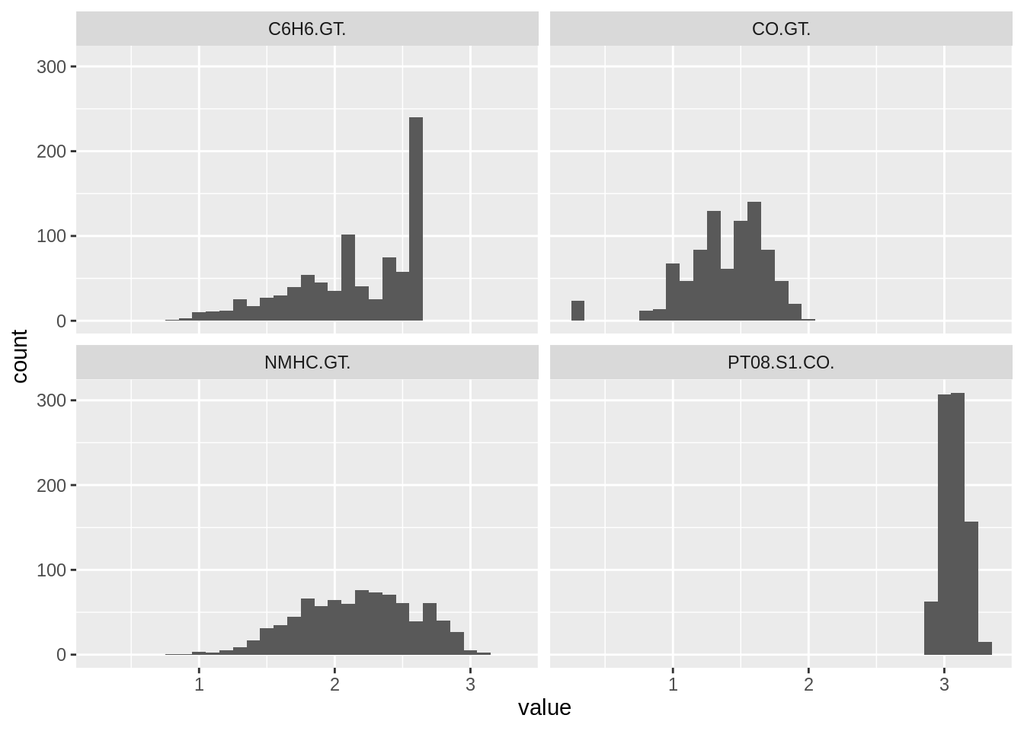

```r
ggplot(gather(airq_data[, c(1:4)], cols, value), aes(x = value)) +
  geom_histogram(binwidth = 0.1) + facet_wrap(.~cols)
```

• Relationships between all variables

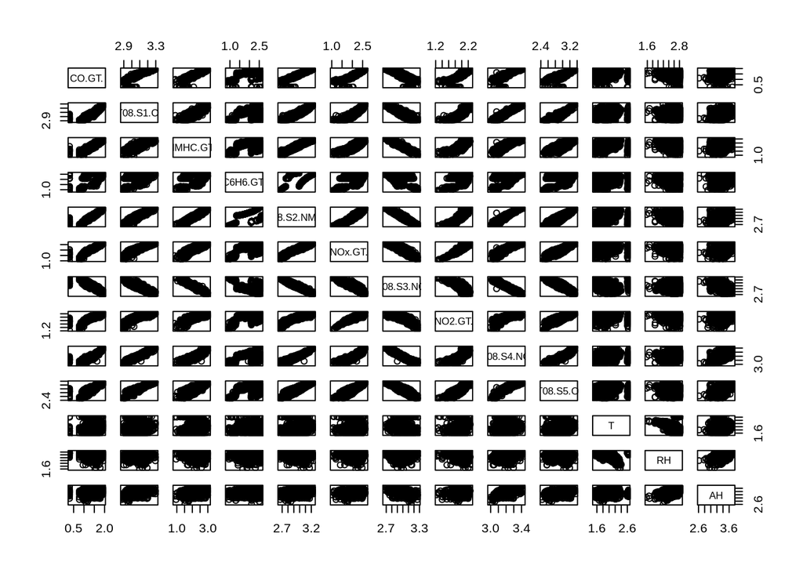

```r
pairs(airq_data)
```

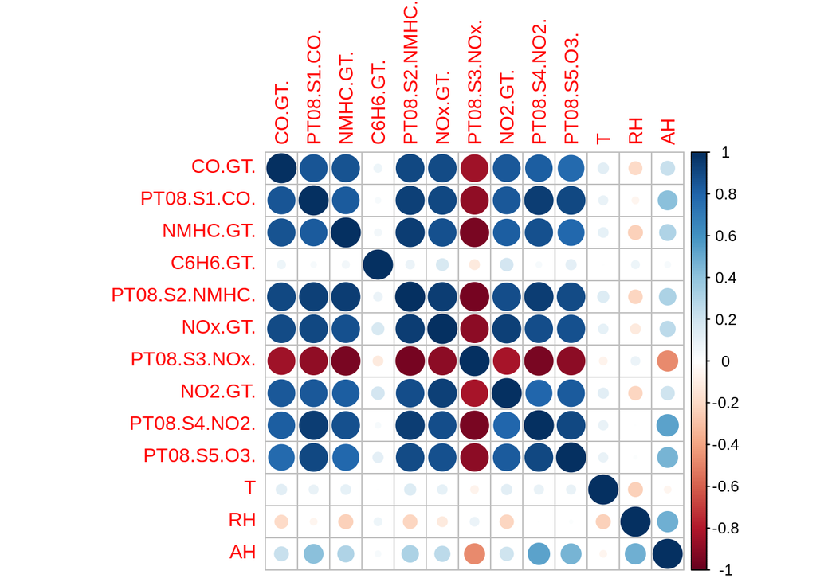

```r
cor_data <- cor(airq_data)
corrplot(cor_data, method = 'circle')
```

We can see that C6H6.GT. doesn’t have a nice correlation with other variables. An if we check the assumptions for each variable we will see, that mostly all of them are not adhered.

Example:

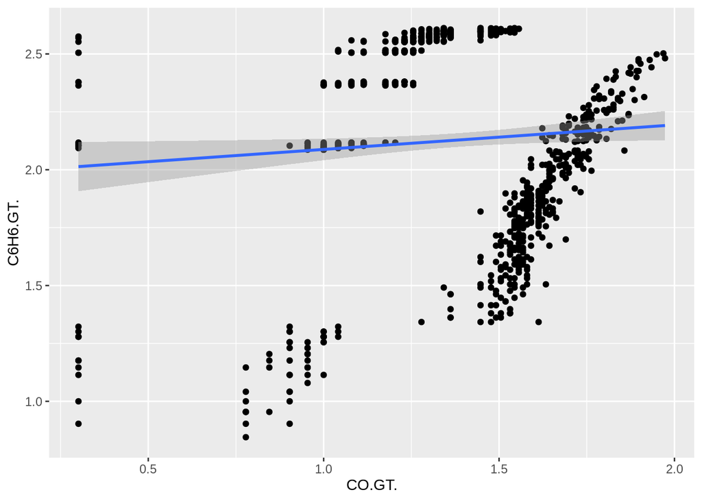

```r
ggplot(airq_data, aes(x = CO.GT., y = C6H6.GT. )) +
  geom_point() +
  geom_smooth(method = 'lm')
```

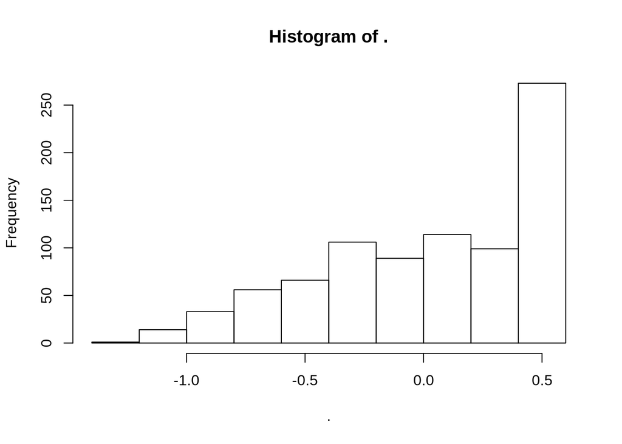

```r
model_CO.GT. <- airq_data  %>%
   lm(data = .,  C6H6.GT. ~ CO.GT.)
residuals(model_CO.GT.) %>% hist()
```

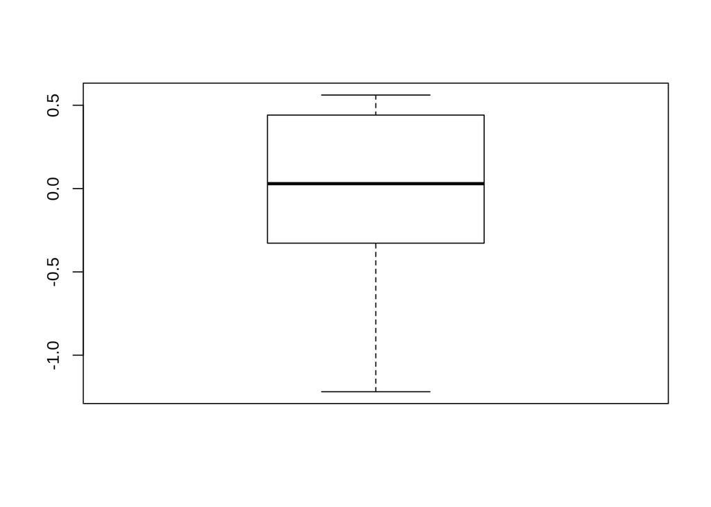

```r
residuals(model_CO.GT.) %>% boxplot()
```

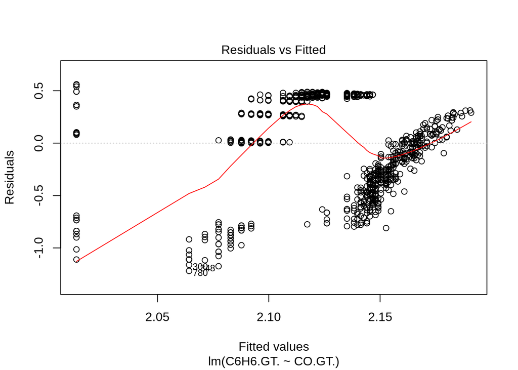

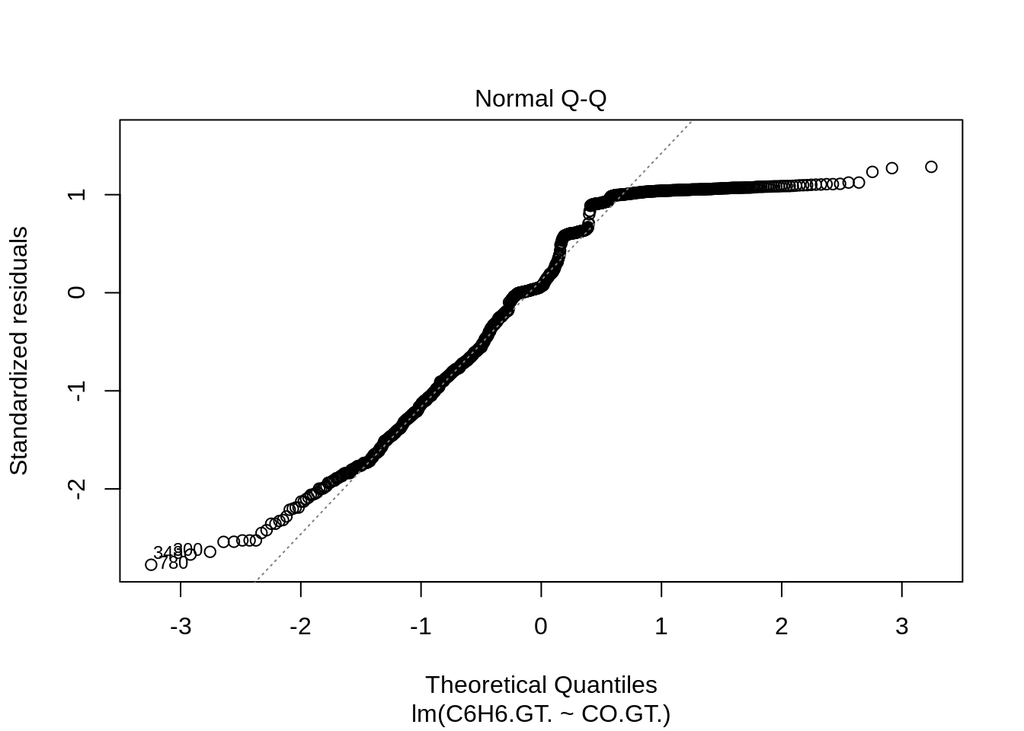

```r
plot(model_CO.GT., which = c(1,2))
```

So I decided to take a PT08.S3.NOx. as a predictor, because for me it seems a little bit better. I checked the assumptions for each variable and took 3 best:

1. NOx.GT.

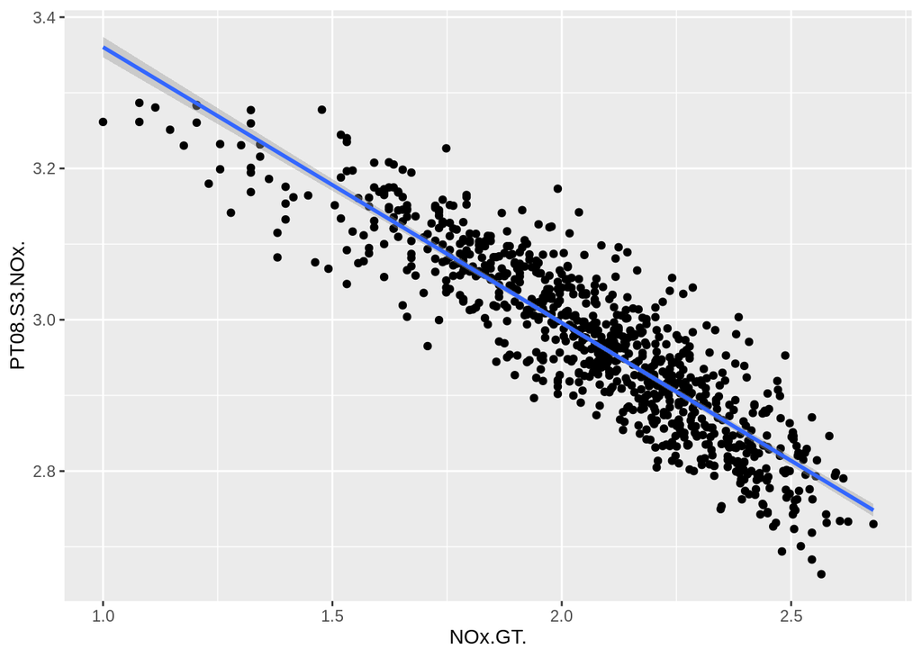

```r
ggplot(airq_data, aes(x = NOx.GT., y = PT08.S3.NOx. )) +
  geom_point() +
  geom_smooth(method = 'lm')
```

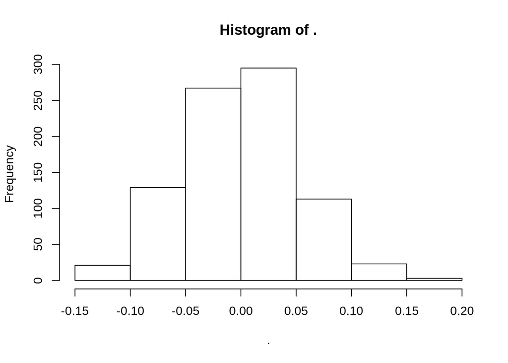

```r
model_NOx.GT. <- airq_data %>% lm(data = ., PT08.S3.NOx. ~ NOx.GT.)
residuals(model_NOx.GT.) %>% hist()
```

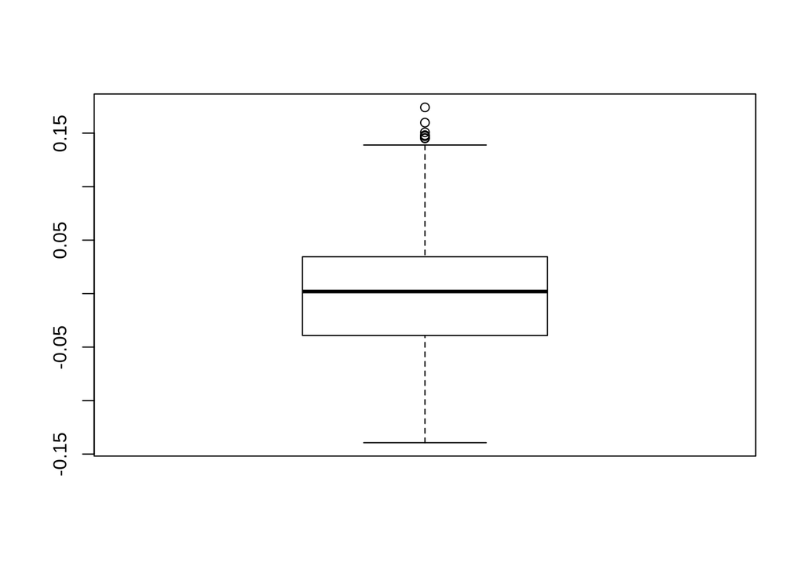

```r
residuals(model_NOx.GT.) %>% boxplot()
```

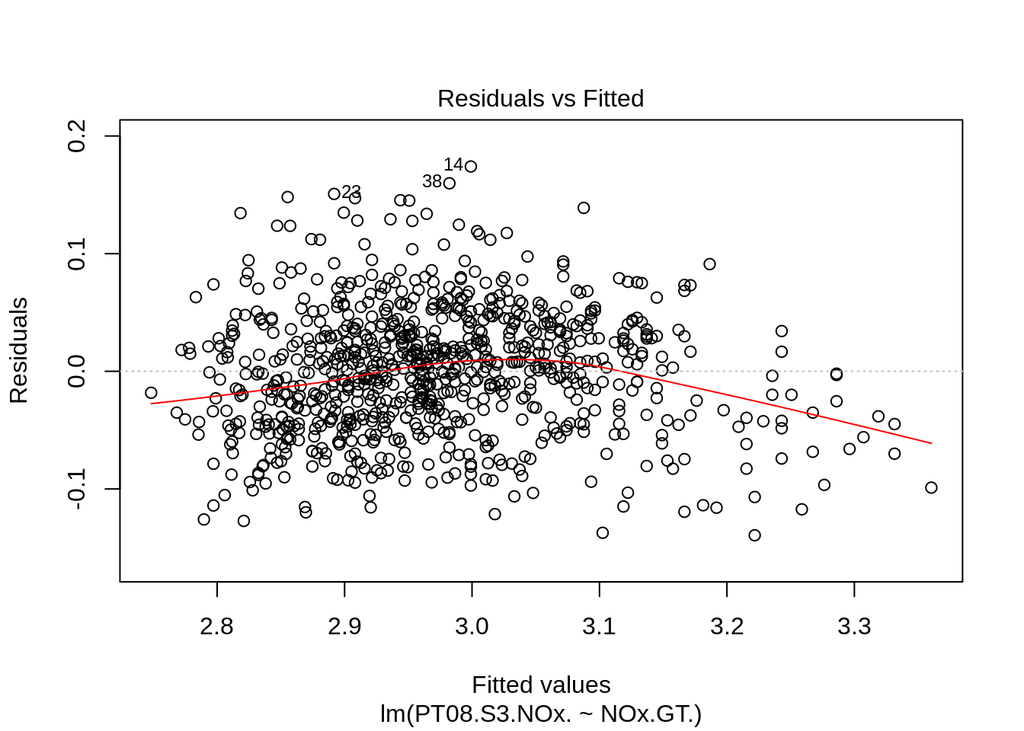

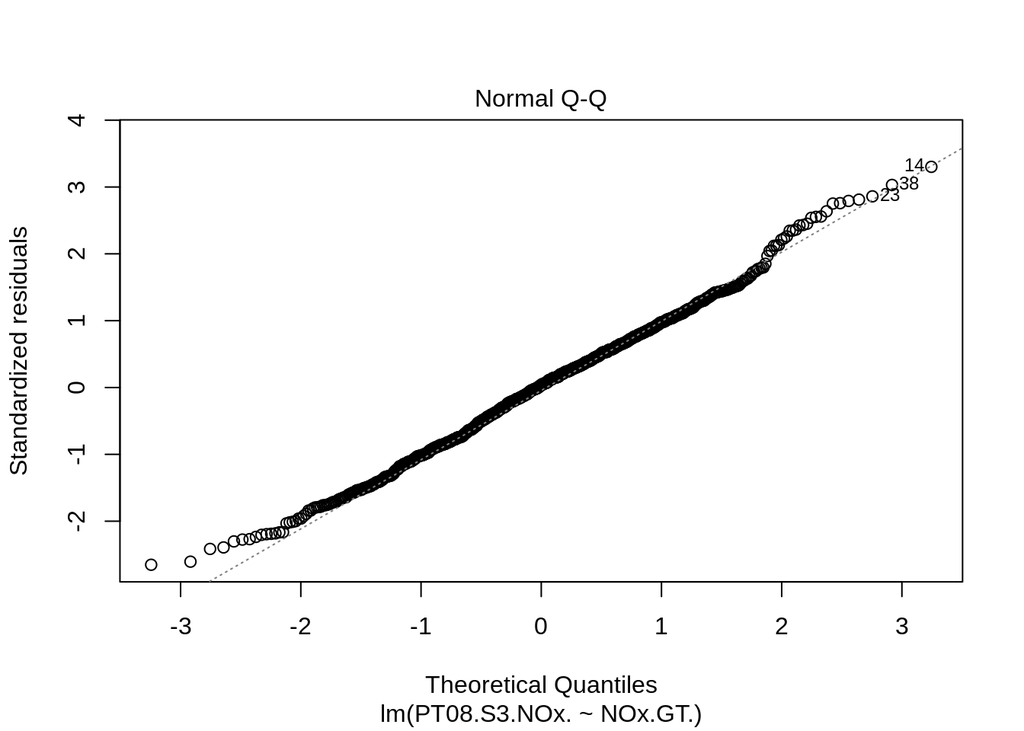

```r
plot(model_NOx.GT., which = c(1,2))
```

```r
summary(model_NOx.GT.)
```

```
##
## Call:
## lm(formula = PT08.S3.NOx. ~ NOx.GT., data = .)
##
## Residuals:
##       Min        1Q    Median        3Q       Max
## -0.139384 -0.039168  0.001901  0.034434  0.174095
##
## Coefficients:
##              Estimate Std. Error t value Pr(>|t|)
## (Intercept)  3.724907   0.013022  286.04   <2e-16 ***
## NOx.GT.     -0.364507   0.006246  -58.36   <2e-16 ***
## ---
## Signif. codes:  0 '***' 0.001 '**' 0.01 '*' 0.05 '.' 0.1 ' ' 1
##
## Residual standard error: 0.05276 on 849 degrees of freedom
## Multiple R-squared:  0.8005, Adjusted R-squared:  0.8002
## F-statistic:  3406 on 1 and 849 DF,  p-value: < 2.2e-16
```

Prediction:

```r
test_subset_NOx.GT. <-  airq_data[which(row.names(airq_data) %in% sample(row.names(airq_data), 25, replace = FALSE)), c(6,7)]
test_NOx.GT. <- data.frame(NOx.GT. = test_subset_NOx.GT.$NOx.GT.)
test_subset_NOx.GT.$pred_PT08.S3.NOx. <- predict(model_NOx.GT., newdata = test_NOx.GT.)
colnames(test_subset_NOx.GT.) <- c('real_NOx.GT.', 'real_PT08.S3.NOx.', 'pred_PT08.S3.NOx.')
head(test_subset_NOx.GT.)
```

|  | real_NOx.GT. | real_PT08.S3.NOx. | pred_PT08.S3.NOx. |
| --- | --- | --- | --- |
| 20 | 2.164353 | 3.065206 | 2.935985 |
| 28 | 2.380211 | 2.980912 | 2.857303 |
| 41 | 2.271842 | 2.959995 | 2.896805 |
| 131 | 1.770852 | 3.119256 | 3.079419 |
| 141 | 2.419956 | 2.888179 | 2.842816 |
| 342 | 1.908485 | 3.074085 | 3.029251 |

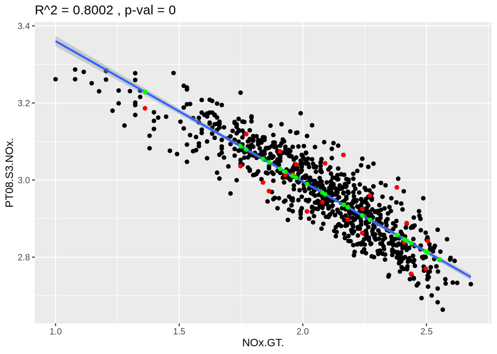

```r
R <- round(summary(model_NOx.GT.)$adj.r.squared, digits = 4)
p <- round(summary(model_NOx.GT.)$coefficients[2,4], digits = 3)
titl <- paste('R^2 =', as.character(R),', p-val =', as.character(p))
ggplot() +
  geom_point(data = airq_data, aes(NOx.GT., PT08.S3.NOx.)) +
  geom_smooth(data = airq_data, aes(NOx.GT., PT08.S3.NOx.), method = 'lm') +
  geom_point(data = test_subset_NOx.GT., aes(real_NOx.GT., real_PT08.S3.NOx.), color = 'red') +
  geom_point(data = test_subset_NOx.GT., aes(real_NOx.GT., pred_PT08.S3.NOx.), color = 'green') +
  labs(title = titl)
```

2. NMHC.GT.

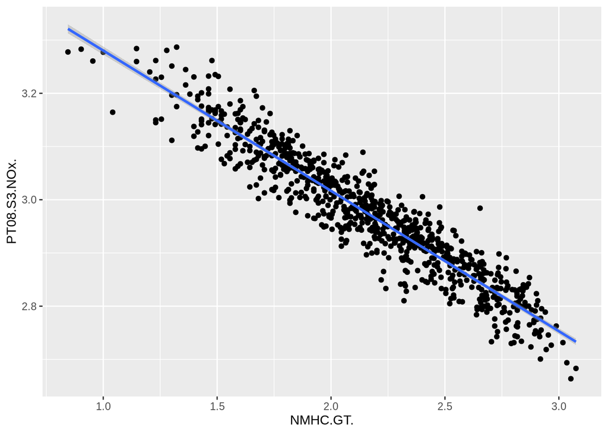

```r
ggplot(airq_data, aes(x = NMHC.GT., y = PT08.S3.NOx.)) +
  geom_point() +
  geom_smooth(method = 'lm')
```

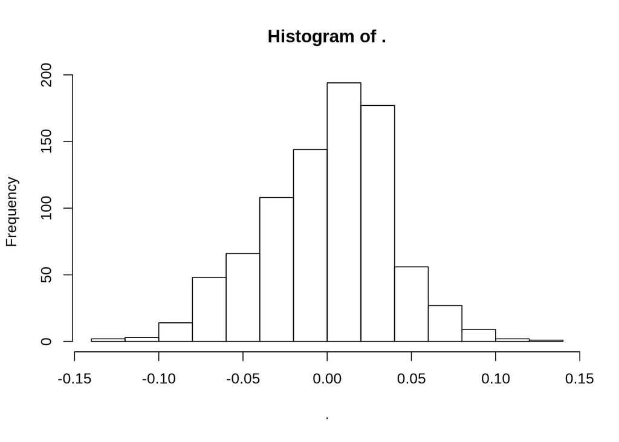

```r
model_NMHC.GT. <- airq_data %>%  lm(data = ., PT08.S3.NOx.~ NMHC.GT.)
residuals(model_NMHC.GT.) %>% hist()
```

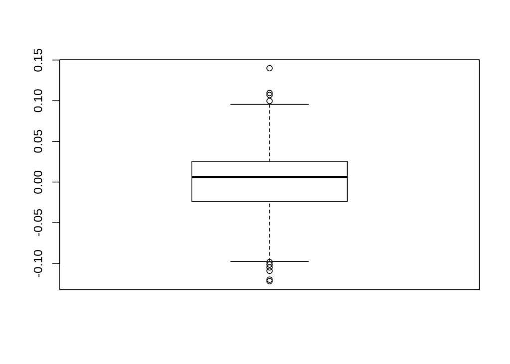

```r
residuals(model_NMHC.GT.) %>% boxplot()
```

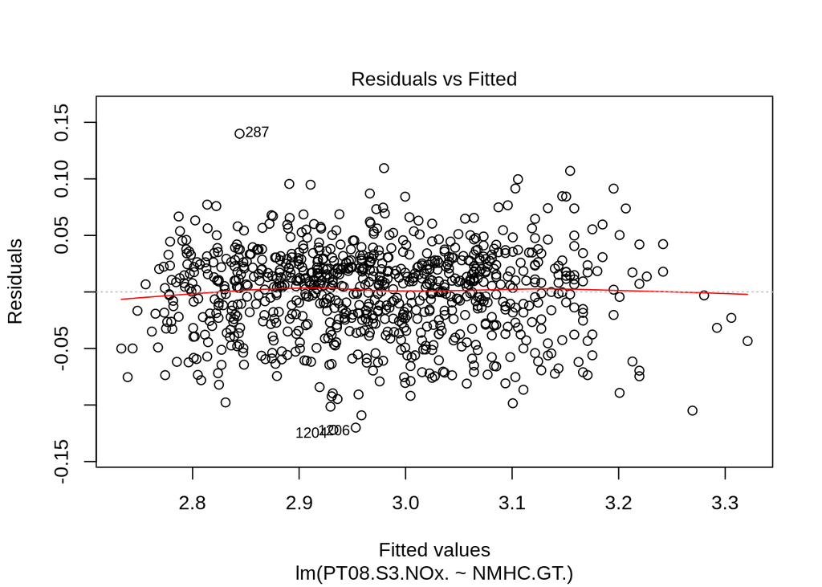

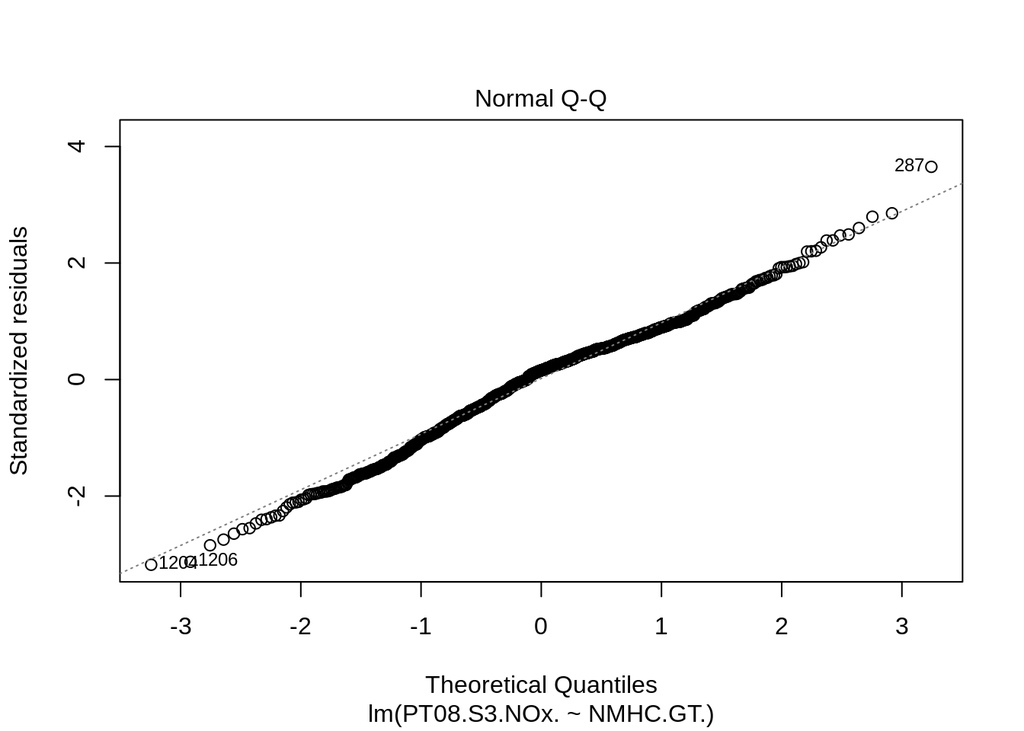

```r
plot(model_NMHC.GT., which = c(1,2))
```

Prediction:

```r
test_subset_NMHC.GT. <-  airq_data[which(row.names(airq_data) %in% sample(row.names(airq_data), 25, replace = FALSE)), c(3,7)]
test_NMHC.GT. <- data.frame(NMHC.GT. = test_subset_NMHC.GT.$NMHC.GT.)
test_subset_NMHC.GT.$pred_PT08.S3.NOx. <- predict(model_NMHC.GT., newdata = test_NMHC.GT.)
colnames(test_subset_NMHC.GT.) <- c('real_NMHC.GT.', 'real_PT08.S3.NOx.', 'pred_PT08.S3.NOx.')
head(test_subset_NMHC.GT.)
```

|  | real_NMHC.GT. | real_PT08.S3.NOx. | pred_PT08.S3.NOx. |
| --- | --- | --- | --- |
| 24 | 2.176091 | 3.003461 | 2.970166 |
| 107 | 1.643453 | 3.060698 | 3.110591 |
| 148 | 2.542825 | 2.845098 | 2.873480 |
| 180 | 1.301030 | 3.111599 | 3.200868 |
| 360 | 2.155336 | 2.985875 | 2.975638 |
| 376 | 2.772322 | 2.833784 | 2.812975 |

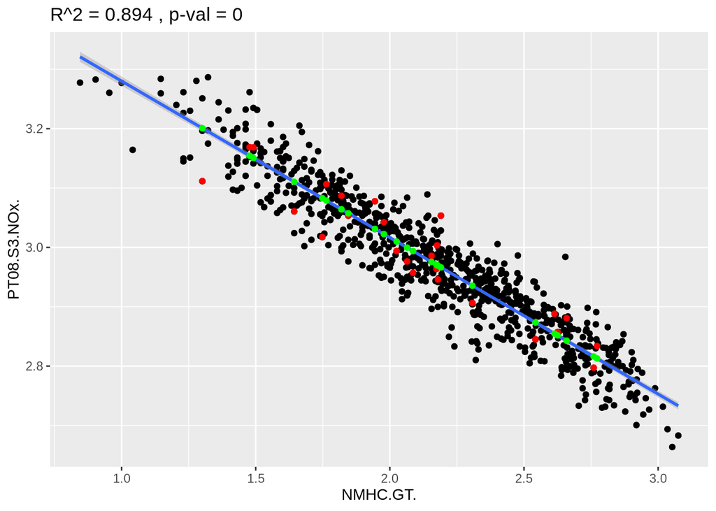

```r
R <- round(summary(model_NMHC.GT.)$adj.r.squared, digits = 3)
p <- round(summary(model_NMHC.GT.)$coefficients[2,4], digits = 3)
titl <- paste('R^2 =', as.character(R),', p-val =', as.character(p))
ggplot() +
  geom_point(data = airq_data, aes(NMHC.GT., PT08.S3.NOx.)) +
  geom_smooth(data = airq_data, aes(NMHC.GT., PT08.S3.NOx.), method = 'lm') +
  geom_point(data = test_subset_NMHC.GT., aes(real_NMHC.GT., real_PT08.S3.NOx.), color = 'red') +
  geom_point(data = test_subset_NMHC.GT., aes(real_NMHC.GT., pred_PT08.S3.NOx.), color = 'green') +
  labs(title = titl)
```

3. PT08.S2.NMHC.

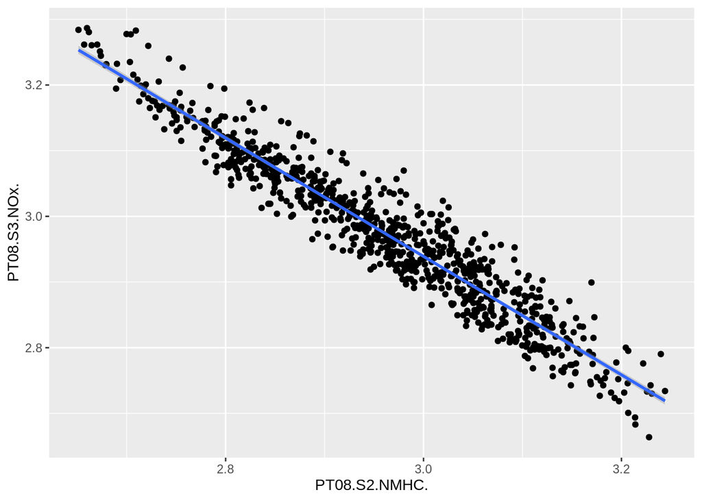

```r
ggplot(airq_data, aes(x = PT08.S2.NMHC., y = PT08.S3.NOx. )) +
  geom_point() +
  geom_smooth(method = 'lm')
```

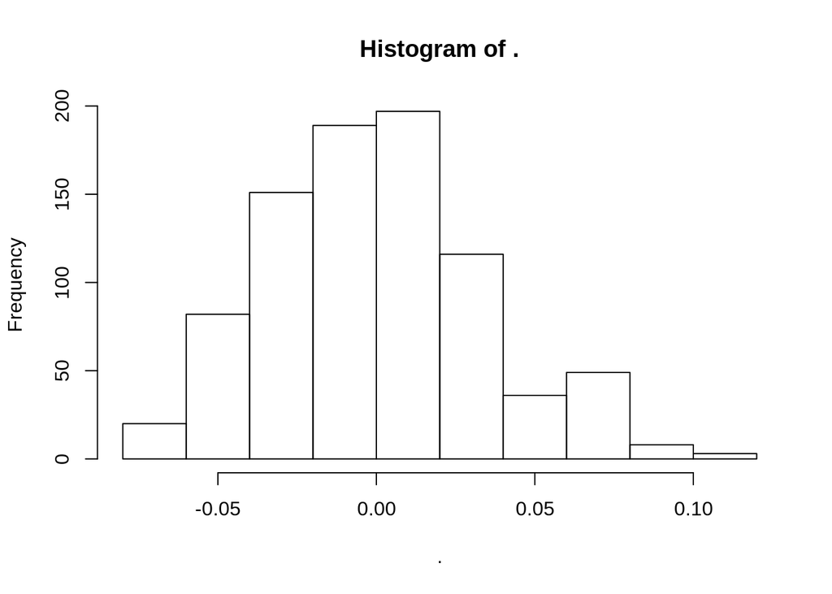

```r
model_PT08.S2.NMHC. <- airq_data  %>% lm(data = .,  PT08.S3.NOx. ~ PT08.S2.NMHC.)
residuals(model_PT08.S2.NMHC.) %>% hist()
```

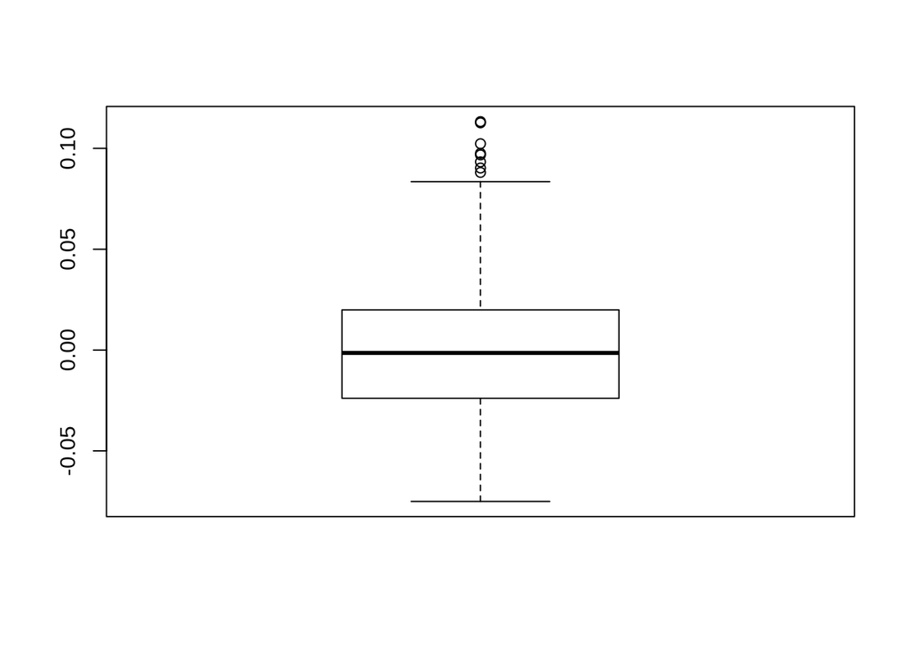

```r
residuals(model_PT08.S2.NMHC.) %>% boxplot()
```

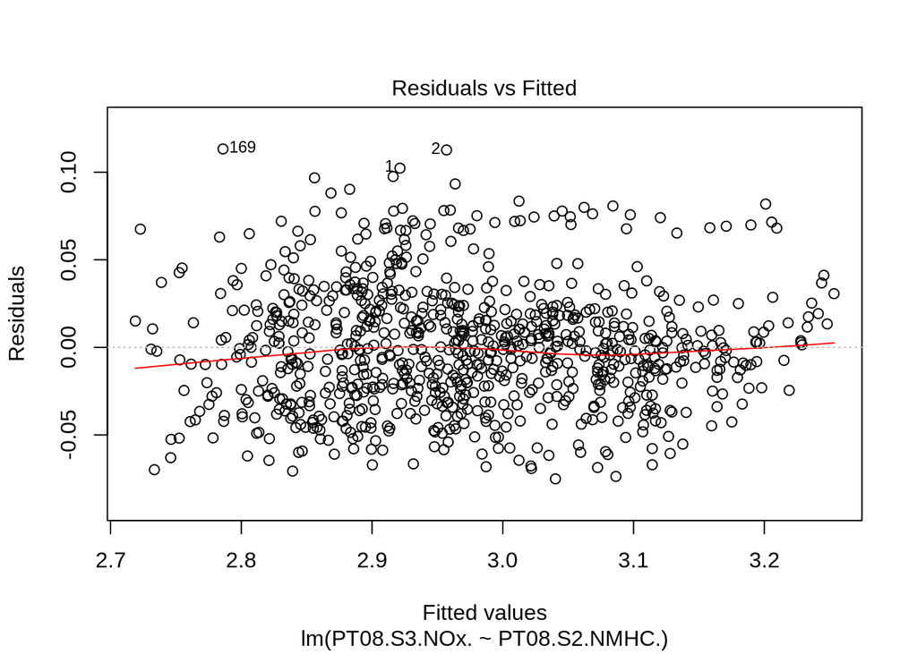

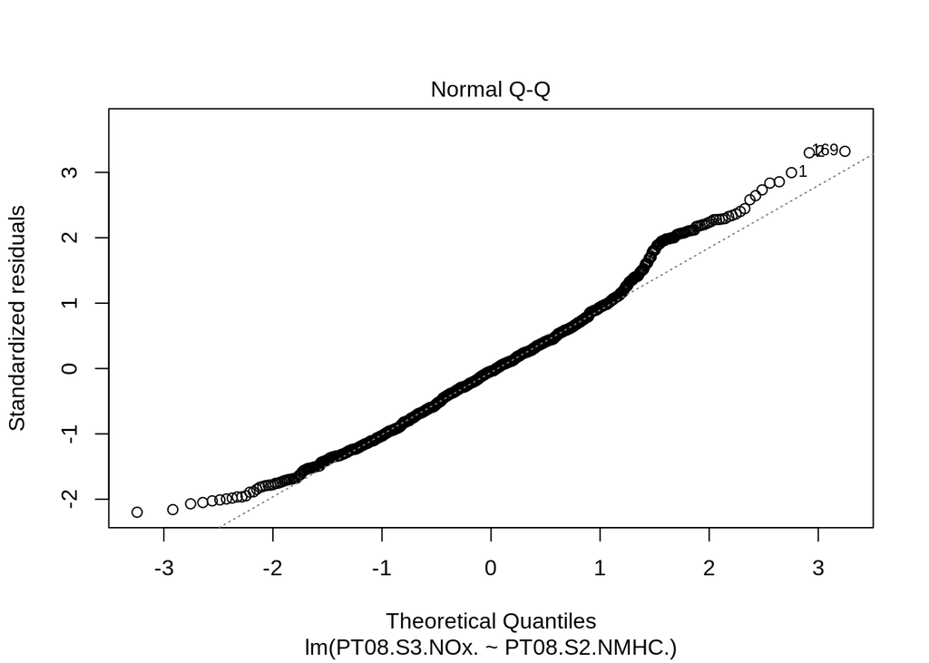

```r
plot(model_PT08.S2.NMHC., which = c(1,2))
```

Prediction:

```r
test_subset_PT08.S2.NMHC. <-  airq_data[which(row.names(airq_data) %in% sample(row.names(airq_data), 25, replace = FALSE)), c(5,7)]
test_PT08.S2.NMHC. <- data.frame(PT08.S2.NMHC. = test_subset_PT08.S2.NMHC.$PT08.S2.NMHC.)
test_subset_PT08.S2.NMHC.$pred_PT08.S3.NOx. <- predict(model_PT08.S2.NMHC., newdata = test_PT08.S2.NMHC.)
colnames(test_subset_PT08.S2.NMHC.) <- c('real_PT08.S2.NMHC.', 'real_PT08.S3.NOx.', 'pred_PT08.S3.NOx.')
head(test_subset_PT08.S2.NMHC.)
```

|  | real_PT08.S2.NMHC. | real_PT08.S3.NOx. | pred_PT08.S3.NOx. |
| --- | --- | --- | --- |
| 9 | 2.784617 | 3.198382 | 3.133118 |
| 26 | 3.172603 | 2.846337 | 2.783364 |
| 98 | 3.117934 | 2.876795 | 2.832646 |
| 132 | 2.767156 | 3.149835 | 3.148859 |
| 171 | 3.221936 | 2.775974 | 2.738892 |
| 306 | 3.066699 | 2.898725 | 2.878833 |

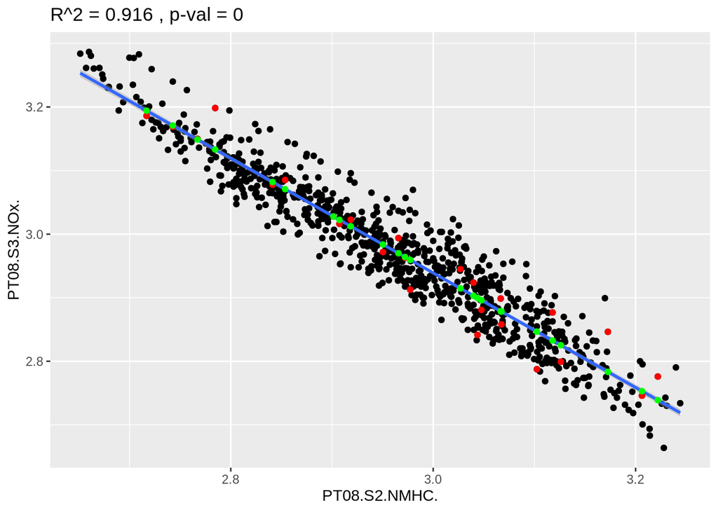

```r
R <- round(summary(model_PT08.S2.NMHC.)$adj.r.squared, digits = 3)
p <- round(summary(model_PT08.S2.NMHC.)$coefficients[2,4], digits = 3)
titl <- paste('R^2 =', as.character(R),', p-val =', as.character(p))
ggplot() +
  geom_point(data = airq_data, aes(PT08.S2.NMHC., PT08.S3.NOx.)) +
  geom_smooth(data = airq_data, aes(PT08.S2.NMHC., PT08.S3.NOx.), method = 'lm') +
  geom_point(data = test_subset_PT08.S2.NMHC., aes(real_PT08.S2.NMHC., real_PT08.S3.NOx.), color = 'red') +
  geom_point(data = test_subset_PT08.S2.NMHC., aes(real_PT08.S2.NMHC., pred_PT08.S3.NOx.), color = 'green') +
  labs(title = titl)
```